# HPC Prediction -- Supervised Learning Applications

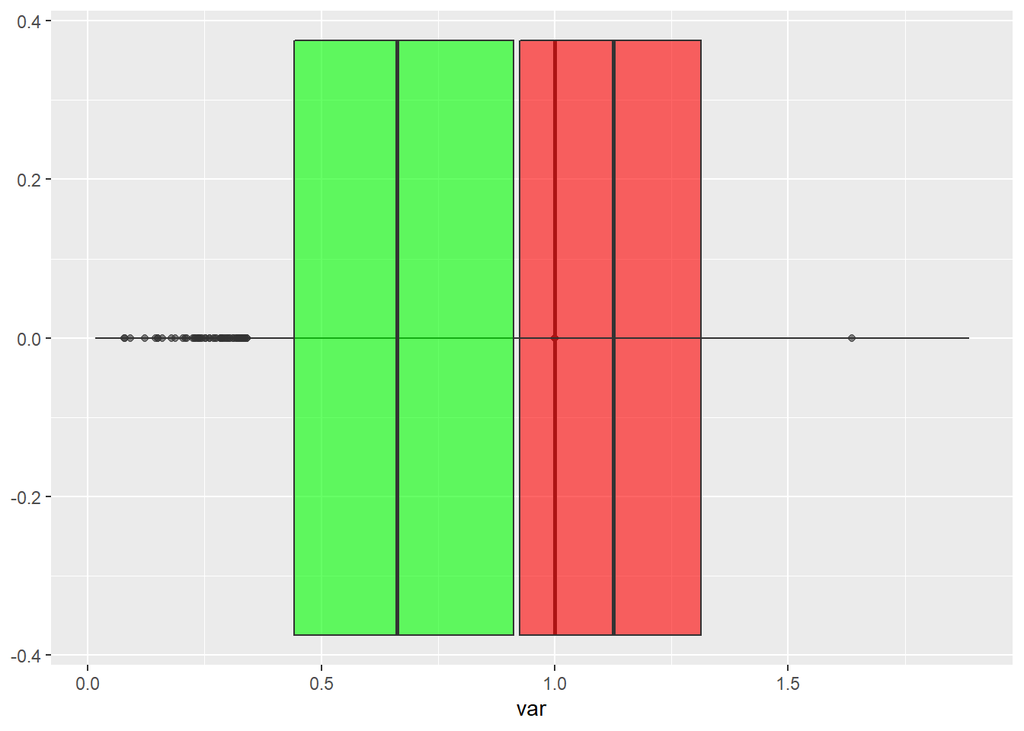

```r
as.data.frame(v[-1:-2,]) %>% ggplot()+
  geom_boxplot(aes(var),fill='blue',alpha=0.6)+
  geom_boxplot(aes(var1),fill='red',alpha=0.6)+
  geom_boxplot(aes(var2),fill='green',alpha=0.6)
```

3. Using the Min-max normalized dataset

```r
var=var1=var2=c(0,0)
for(i in 3:ncol(df)){
  var[i] = var(df_M[,i]) #overall variance
  var1[i] = var(df_M[1:181,i]) #variance over HCC cases
  var2[i] = var(df_M[182:357,i]) #variance over normal patients
}
```

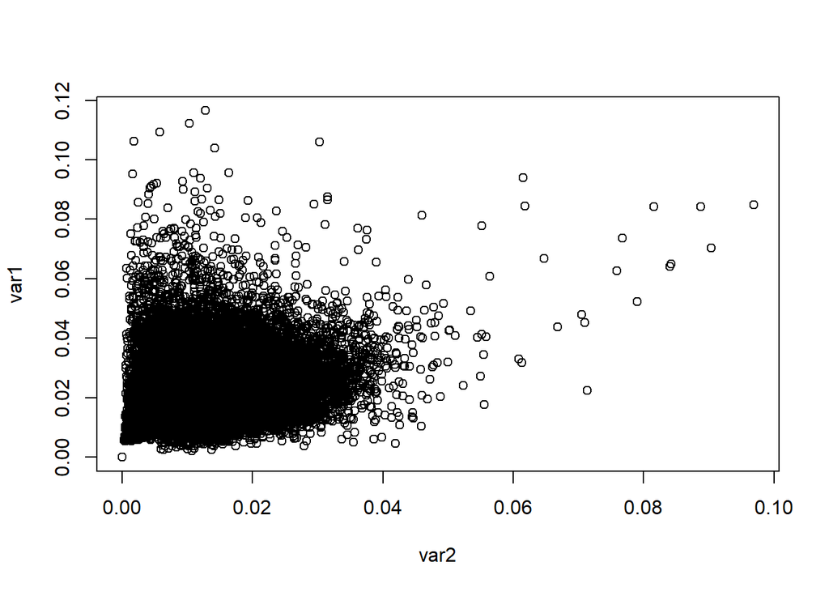

```r
plot(var1~var2)
```

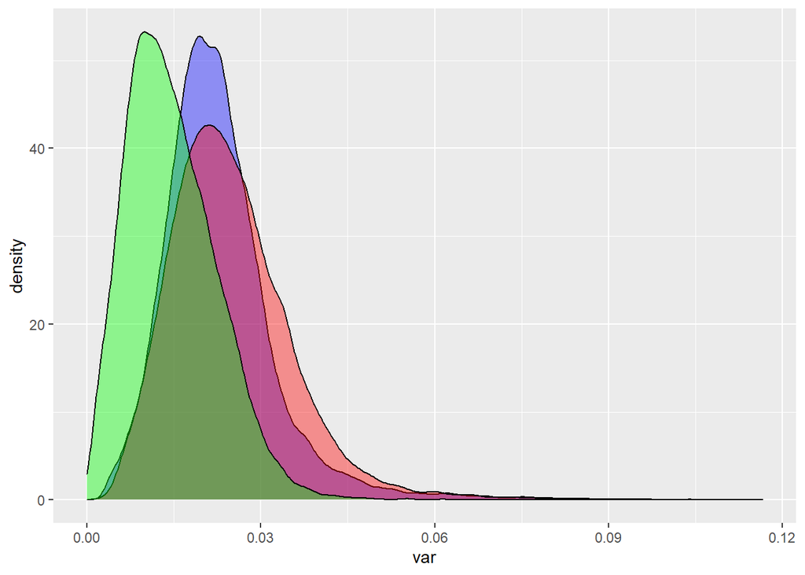

```r
v=cbind(var,var1,var2)
as.data.frame(v) %>% ggplot()+
  geom_density(aes(var),fill='blue',alpha=0.4)+
  geom_density(aes(var1),fill='red',alpha=0.4)+
  geom_density(aes(var2),fill='green',alpha=0.4)
```

```r
max=0
for (i in var){
  if(i>max){
    max=i
  }
}
print(max)
```

```
## [1] 0.1099716
```

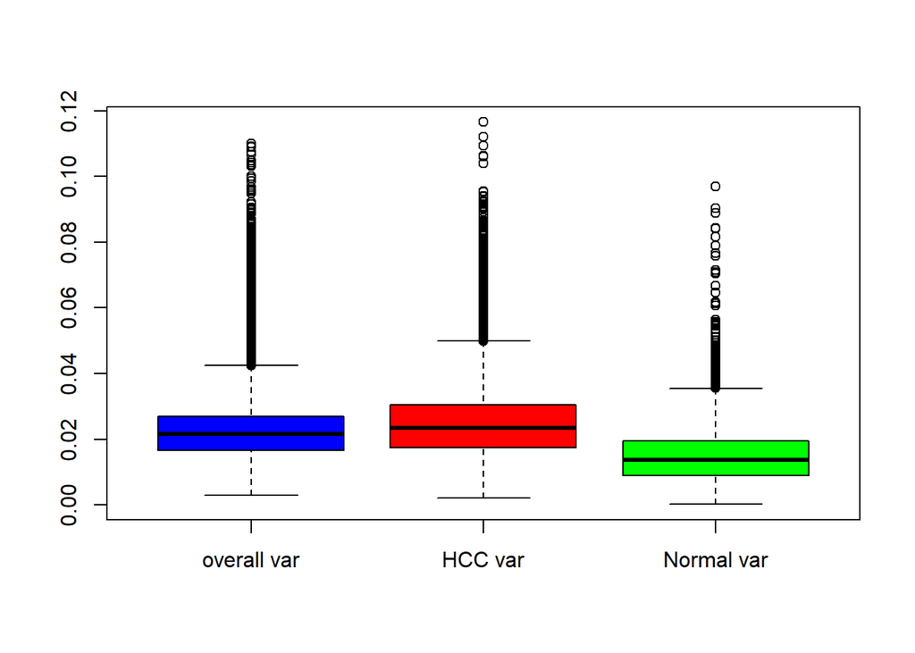

```r
v=cbind(var,var1,var2)
boxplot(v[-1:-2,],col=c('blue','red','green'),names=c('overall var','HCC var', 'Normal var'))
```

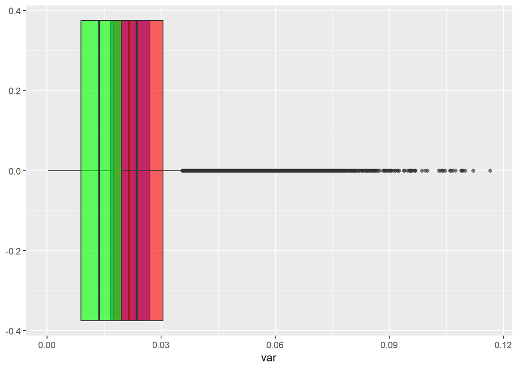

```r
as.data.frame(v[-1:-2,]) %>% ggplot()+
  geom_boxplot(aes(var),fill='blue',alpha=0.6)+
  geom_boxplot(aes(var1),fill='red',alpha=0.6)+
  geom_boxplot(aes(var2),fill='green',alpha=0.6)
```

4. Usinf the Robust scalar normalized dataset

```r
var=var1=var2=c(0,0)
for(i in 3:ncol(df_R)){
  var[i] = var(df_R[,i]) #overall variance
  var1[i] = var(df_R[1:181,i]) #variance over HCC cases
  var2[i] = var(df_R[182:357,i]) #variance over normal patients
}
```

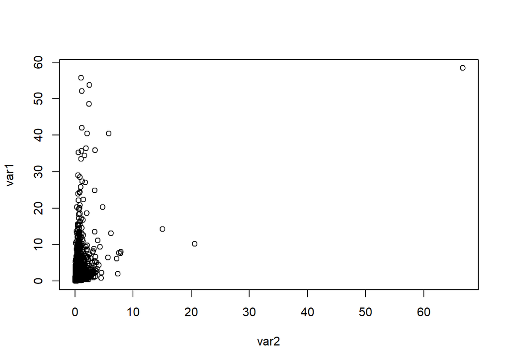

```r
plot(var1~var2)
```

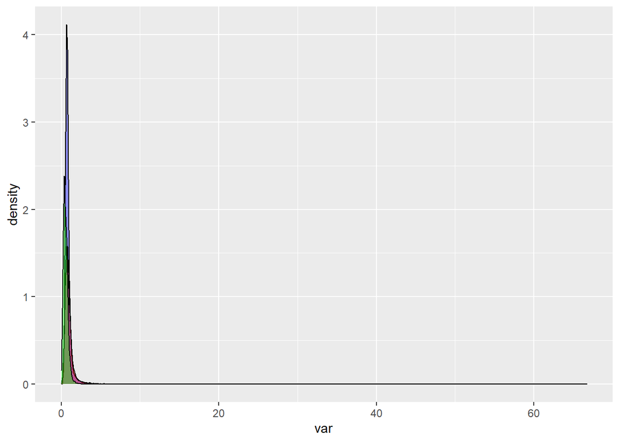

```r
v=cbind(var,var1,var2)
as.data.frame(v) %>% ggplot()+
  geom_density(aes(var),fill='blue',alpha=0.4)+
  geom_density(aes(var1),fill='red',alpha=0.4)+
  geom_density(aes(var2),fill='green',alpha=0.4)
```

```r
max=0
for (i in var){
  if(i>max){
    max=i
  }
}
print(max)
```

```
## [1] 62.32347
```

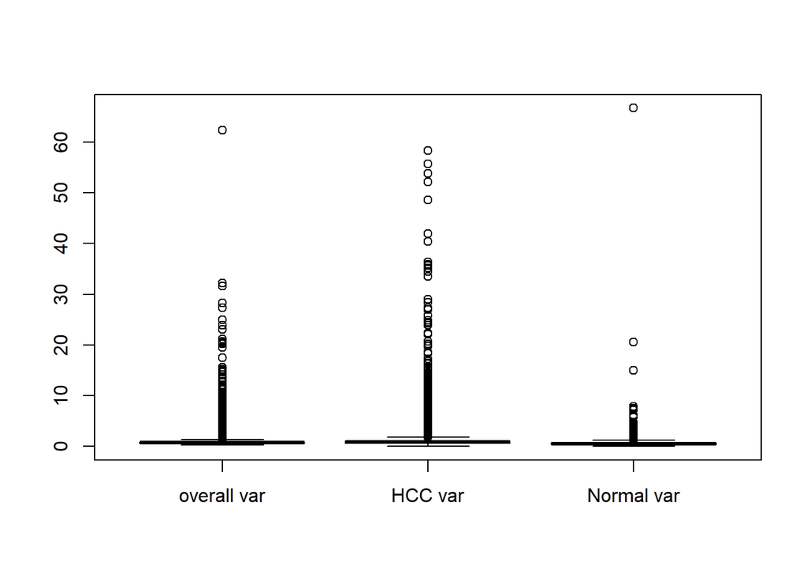

```r
v=cbind(var,var1,var2)
boxplot(v[-1:-2,],col=c('blue','red','green'),names=c('overall var','HCC var', 'Normal var'))
```

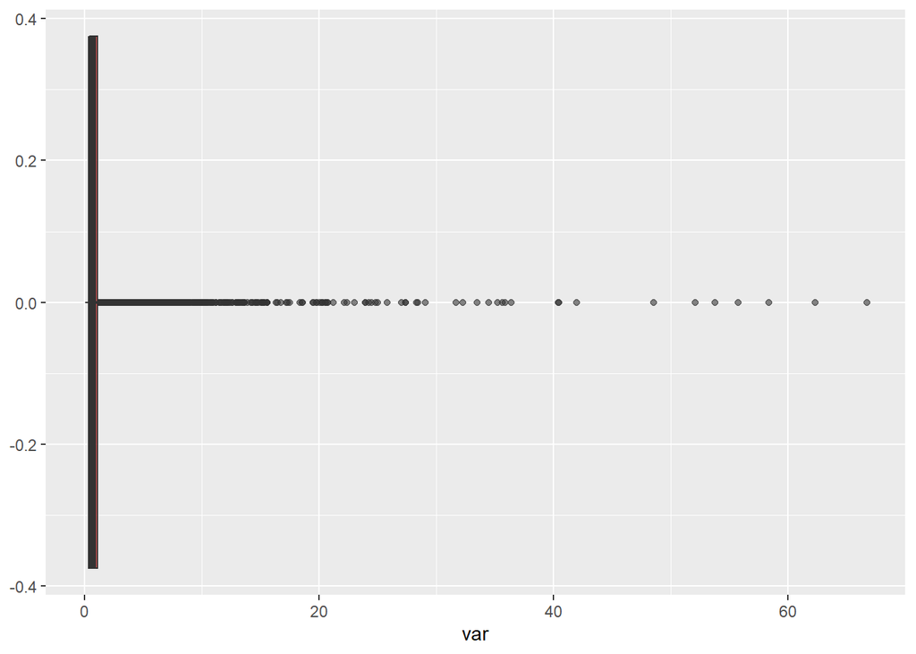

```r
as.data.frame(v[-1:-2,]) %>% ggplot()+
  geom_boxplot(aes(var),fill='blue',alpha=0.6)+
  geom_boxplot(aes(var1),fill='red',alpha=0.6)+
  geom_boxplot(aes(var2),fill='green',alpha=0.6)
```

Regarding the parts 2,3, and 4, it can be seen that normalizing the data in different ways results in very different patterns allowing for potential different approaches for optimal genes selection to include in the model. A very good model was already reached using the genes with the most variability in the original sample, yet it is apparent that this is not the optimal approach, since the different genes has different scales and thus what might be a very high variance score for one, might as well not be as high or be even low for another. That is why this approach does not allow much understanding of the contribution of each selected gene, and it is expected that it would not be as good as other approaches relying on the normalized data.

A quick inspection of the results shows that the robust normalization drags most variability across genes (and across normal and HCC cases) towards 0, leaving a handful of genes with very high variance reaching approximately 60 as maximum. This suggests that those exceptional genes might be good to use in the model.

On the other hand, the standardization technique is shown to result in the most linear-like distribution of variability across the normal and HCC cases, which is expected due to the fact that it makes the overall variance 1 across all genes. This suggests that relying on this dataset might offer the selection approach with the best control over the independent variability of the selected genes over the normal and HCC cases.

Yet, this also raises the issue of potential bias introduced by segregating the variance based on the categories to be predicted. So also whether this approach or the completely unsupervised one is better remains to be investigated. Some work with the standardized dataset will be done below (selection of genes with lowest variance among normal cases).

As for the min-max approach, it is shown to give the most similar results to the original dataset, yet it allows for a much narrower range of variation (of the variances themselves), allowing for easier inspection of the plots and more clear understanding of the relations and comparisons between the genes. These advantages likely emerged at the expense of poor conservation of the outliers, which might be important in this context.

Due to limited time, most of these considerations will be left to the next phase.

3. Resampling

Different resampling techniques are used over the different sections. Here, the results of the different resampling techniques will be compared for 1 model.

```r
mut_df = mut_df%>%
  mutate(id=row_number())

set.seed(123,sample.kind='Rejection')

training = mut_df%>%
  slice_sample(prop=0.7)
nrow(training)
```

```
## [1] 249
```

```r
testing = anti_join(mut_df,training,by='id')
nrow(testing)
```

```
## [1] 108
```

```r
training = training%>%
  dplyr::select(-id)
testing = testing%>%
  dplyr::select(-id)

model = glm(type~.,training[-1],family=binomial())

probs <- predict(model, newdata = testing,type='response')
pred <- rep("HCC",nrow(testing))
pred[probs > 0.5] <- "normal"

t = confusionMatrix(as.factor(pred), reference=as.factor(testing$type))
t
```

```
## Confusion Matrix and Statistics
##
##           Reference
## Prediction HCC normal
##     HCC     45      3
##     normal   8     52
##
##                Accuracy : 0.8981
##                  95% CI : (0.8251, 0.948)
##     No Information Rate : 0.5093
##     P-Value [Acc > NIR] : <2e-16
##
##                   Kappa : 0.7959
##
##  Mcnemar's Test P-Value : 0.2278
##
##             Sensitivity : 0.8491
##             Specificity : 0.9455
##          Pos Pred Value : 0.9375
##          Neg Pred Value : 0.8667
##              Prevalence : 0.4907
##          Detection Rate : 0.4167
##    Detection Prevalence : 0.4444
##       Balanced Accuracy : 0.8973
##
##        'Positive' Class : HCC
##
```

```r
mut_df=mut_df[-ncol(mut_df)]
```

The validation set approach is not very reliable since its result can be shown to fluctuate when repeated, depending on the random choice of the testing and training samples.

```r
train_control <- trainControl(method = "LOOCV")

model <- train(type ~., mut_df[-1],
            method = "glm",
            trControl = train_control)

print(model)
```

```
## Generalized Linear Model
##
## 357 samples
##  22 predictor
##   2 classes: 'HCC', 'normal'
##
## No pre-processing
## Resampling: Leave-One-Out Cross-Validation
## Summary of sample sizes: 356, 356, 356, 356, 356, 356, ...
## Resampling results:
##
##   Accuracy   Kappa
##   0.9327731  0.865562
```

```r
train_control <- trainControl(method = "cv",
                              number = 10)

model <- train(type ~., mut_df[-1],
            method = "glm",
            trControl = train_control)


print(model)
```

```
## Generalized Linear Model
##
## 357 samples
##  22 predictor
##   2 classes: 'HCC', 'normal'
##
## No pre-processing
## Resampling: Cross-Validated (10 fold)
## Summary of sample sizes: 321, 321, 321, 322, 322, 321, ...
## Resampling results:
##
##   Accuracy   Kappa
##   0.9411905  0.8823528
```

```r
train_control <- trainControl(method = "repeatedcv",
                            number = 10, repeats = 3)

model <- train(type ~., mut_df[-1],
            method = "glm",
            trControl = train_control)


print(model)
```

```
## Generalized Linear Model
##
## 357 samples
##  22 predictor
##   2 classes: 'HCC', 'normal'
##
## No pre-processing
## Resampling: Cross-Validated (10 fold, repeated 3 times)
## Summary of sample sizes: 322, 322, 321, 321, 320, 322, ...
## Resampling results:
##
##   Accuracy   Kappa
##   0.9309996  0.8620549
```

It can be seen that for the considered model, all the techniques gave very similar results. Yet, the most reliable approach would be the one using repeated k-cv, since it will return the most accurate estimate of the accuracy.

4. Penalized logistic regression

Next the use of penalized models (such as LASSO) will be considered. These models are well suited to the case where the number of predictors > number of observations, and whereby potential correlations within the predictors exist as the case was shown to be here.

```r
require(nnet)
library(glmnet)
model = glmnet(as.matrix(df[-1:-2]),df[,2],family=binomial(),alpha=1,lambda=NULL)
model
```

```
##
## Call:  glmnet(x = as.matrix(df[-1:-2]), y = df[, 2], family = binomial(),      alpha = 1, lambda = NULL)
##
##     Df  %Dev  Lambda
## 1    0  0.00 0.44440
## 2    2  5.23 0.42420
## 3    2 10.05 0.40490
## 4    2 14.47 0.38650
## 5    2 18.55 0.36890
## 6    2 22.32 0.35220
## 7    3 25.81 0.33610
## 8    3 29.08 0.32090
## 9    3 32.13 0.30630
## 10   4 34.98 0.29240
## 11   4 37.69 0.27910
```

[output cut: 89 more lines]

The results displays the different produced models (with their lambdas). %Dev is used to monitor the models, so that when it stops showing much change no more models are generated. The below plots are used to visualize the results.

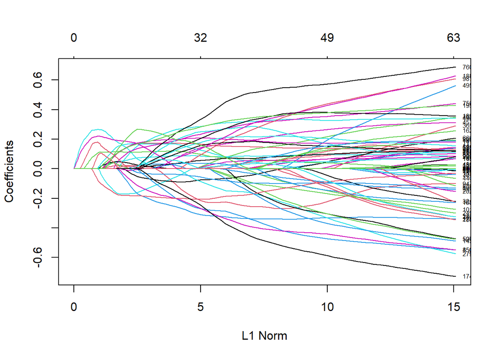

```r
plot(model,label=TRUE,xvar='norm')
```

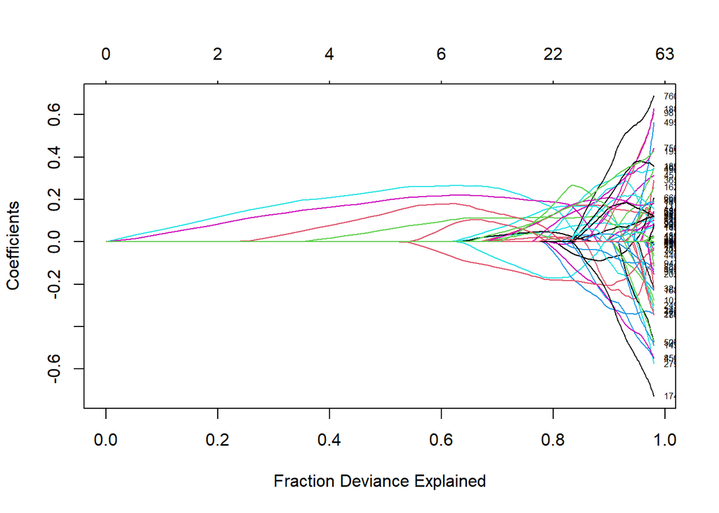

```r
plot(model,label=TRUE,xvar='dev')
```

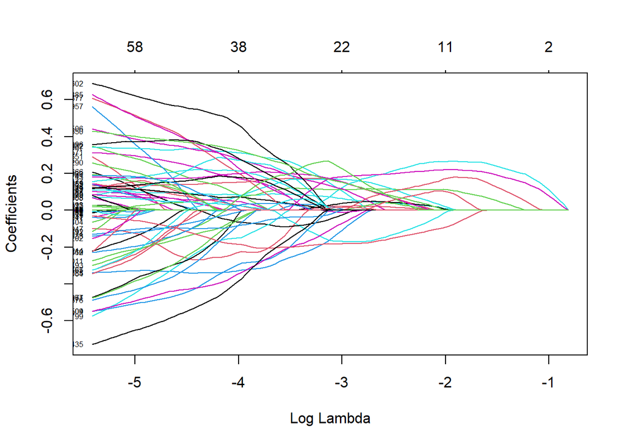

```r
plot(model,label=TRUE,xvar='lambda')
```

Next, the genes selected in the model with the minimum lambda are displayed. The minimum lambda point is also inspected.

```r
model.cv = cv.glmnet(as.matrix(df[-1:-2]),df[,2],family=binomial(),alpha=1,nfolds=5)
x=coef(model.cv,s='lambda.min')
for(i in 2:length(x)){
  if(x[i]!=0){
   print(colnames(df)[i+1])
  }
}
```

```
## [1] "X201419_at"
## [1] "X201483_s_at"
## [1] "X201599_at"
## [1] "X201656_at"
## [1] "X202964_s_at"
## [1] "X203258_at"
## [1] "X203272_s_at"
## [1] "X204977_at"
## [1] "X205044_at"
## [1] "X205307_s_at"
## [1] "X205405_at"
## [1] "X205440_s_at"
## [1] "X205544_s_at"
## [1] "X205728_at"
## [1] "X205740_s_at"
```

[output cut: 28 more lines]

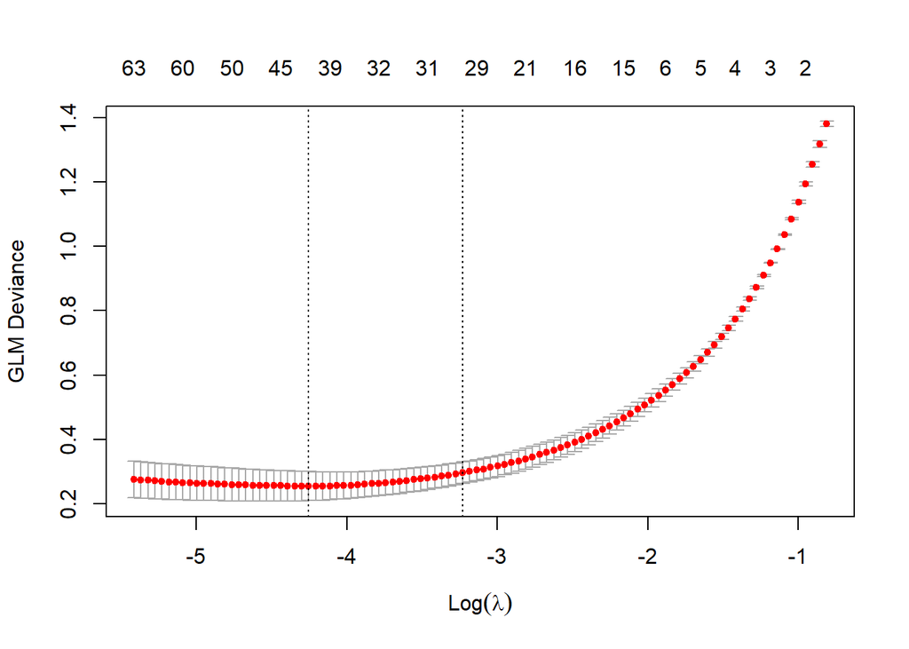

```r
plot(model.cv)
```

```r
model.cv$lambda.min
```

```
## [1] 0.01421649
```

```r
probs <- predict(model.cv, newx = as.matrix(df[-1:-2]), s = "lambda.min")
contrasts(df$type)
```

```
##        normal
## HCC         0
## normal      1
```

```r
pred <- rep("HCC",nrow(df))
pred[probs > 0.5] <- "normal"
pred
```

```
##   [1] "HCC"    "HCC"    "HCC"    "HCC"    "HCC"    "HCC"    "HCC"    "HCC"
##   [9] "HCC"    "HCC"    "HCC"    "HCC"    "HCC"    "HCC"    "HCC"    "HCC"
##  [17] "HCC"    "HCC"    "HCC"    "HCC"    "HCC"    "HCC"    "HCC"    "HCC"
##  [25] "HCC"    "HCC"    "HCC"    "HCC"    "HCC"    "HCC"    "HCC"    "HCC"
##  [33] "HCC"    "HCC"    "HCC"    "HCC"    "HCC"    "HCC"    "HCC"    "HCC"
##  [41] "HCC"    "HCC"    "HCC"    "HCC"    "HCC"    "HCC"    "HCC"    "HCC"
##  [49] "HCC"    "HCC"    "HCC"    "HCC"    "HCC"    "HCC"    "HCC"    "HCC"
##  [57] "HCC"    "HCC"    "HCC"    "HCC"    "HCC"    "HCC"    "HCC"    "HCC"
##  [65] "HCC"    "HCC"    "HCC"    "HCC"    "HCC"    "HCC"    "HCC"    "HCC"
##  [73] "HCC"    "HCC"    "HCC"    "HCC"    "HCC"    "HCC"    "HCC"    "HCC"
##  [81] "HCC"    "HCC"    "HCC"    "HCC"    "HCC"    "HCC"    "HCC"    "HCC"
##  [89] "HCC"    "HCC"    "HCC"    "HCC"    "HCC"    "HCC"    "HCC"    "HCC"
##  [97] "HCC"    "HCC"    "HCC"    "HCC"    "HCC"    "HCC"    "HCC"    "HCC"
## [105] "HCC"    "HCC"    "HCC"    "HCC"    "HCC"    "HCC"    "HCC"    "HCC"
## [113] "HCC"    "HCC"    "HCC"    "HCC"    "HCC"    "HCC"    "HCC"    "HCC"
```

[output cut: 30 more lines]

```r
t = confusionMatrix(as.factor(pred), reference=as.factor(df$type))
t
```

```
## Confusion Matrix and Statistics
##
##           Reference
## Prediction HCC normal
##     HCC    180      1
##     normal   1    175
##
##                Accuracy : 0.9944
##                  95% CI : (0.9799, 0.9993)
##     No Information Rate : 0.507
##     P-Value [Acc > NIR] : <2e-16
##
##                   Kappa : 0.9888
##
##  Mcnemar's Test P-Value : 1
##
##             Sensitivity : 0.9945
##             Specificity : 0.9943
##          Pos Pred Value : 0.9945
##          Neg Pred Value : 0.9943
##              Prevalence : 0.5070
##          Detection Rate : 0.5042
##    Detection Prevalence : 0.5070
##       Balanced Accuracy : 0.9944
##
##        'Positive' Class : HCC
##
```

```r
probs = predict(model, as.matrix(df[-1][-1]), s = 0.3)
pred <- rep("HCC",nrow(df))
pred[probs > 0.5] <- "normal"
pred
```

```
##   [1] "HCC"    "HCC"    "HCC"    "HCC"    "HCC"    "HCC"    "HCC"    "normal"
##   [9] "HCC"    "HCC"    "HCC"    "HCC"    "HCC"    "HCC"    "HCC"    "HCC"
##  [17] "HCC"    "HCC"    "HCC"    "HCC"    "HCC"    "HCC"    "HCC"    "HCC"
##  [25] "HCC"    "HCC"    "HCC"    "HCC"    "HCC"    "HCC"    "HCC"    "HCC"
##  [33] "HCC"    "HCC"    "HCC"    "HCC"    "HCC"    "HCC"    "HCC"    "HCC"
##  [41] "HCC"    "HCC"    "HCC"    "HCC"    "HCC"    "HCC"    "HCC"    "HCC"
##  [49] "HCC"    "HCC"    "HCC"    "HCC"    "HCC"    "HCC"    "HCC"    "HCC"
##  [57] "HCC"    "HCC"    "HCC"    "HCC"    "HCC"    "HCC"    "HCC"    "HCC"
##  [65] "HCC"    "HCC"    "HCC"    "HCC"    "HCC"    "HCC"    "HCC"    "HCC"
##  [73] "HCC"    "HCC"    "HCC"    "HCC"    "HCC"    "HCC"    "HCC"    "HCC"
##  [81] "HCC"    "HCC"    "HCC"    "HCC"    "HCC"    "HCC"    "HCC"    "HCC"
##  [89] "HCC"    "HCC"    "HCC"    "HCC"    "HCC"    "HCC"    "HCC"    "HCC"
##  [97] "HCC"    "HCC"    "HCC"    "HCC"    "HCC"    "HCC"    "HCC"    "HCC"
## [105] "HCC"    "HCC"    "HCC"    "HCC"    "HCC"    "HCC"    "HCC"    "HCC"
## [113] "HCC"    "HCC"    "HCC"    "HCC"    "HCC"    "HCC"    "HCC"    "HCC"
```

[output cut: 30 more lines]

```r
t = confusionMatrix(as.factor(pred), reference=as.factor(df$type))
t
```

```
## Confusion Matrix and Statistics
##
##           Reference
## Prediction HCC normal
##     HCC    178     68
##     normal   3    108
##
##                Accuracy : 0.8011
##                  95% CI : (0.7559, 0.8413)
##     No Information Rate : 0.507
##     P-Value [Acc > NIR] : < 2.2e-16
##
##                   Kappa : 0.6001
##
##  Mcnemar's Test P-Value : 3.068e-14
##
##             Sensitivity : 0.9834
##             Specificity : 0.6136
##          Pos Pred Value : 0.7236
##          Neg Pred Value : 0.9730
##              Prevalence : 0.5070
##          Detection Rate : 0.4986
##    Detection Prevalence : 0.6891
##       Balanced Accuracy : 0.7985
##
##        'Positive' Class : HCC
##
```

The training accuracy for the model with min lambda exceeded 98%. The training accuracy for another value of lambda (0.3) is also showed.

```r
df = df%>%
  mutate(id=row_number())

training = df%>%
  slice_sample(prop=0.7)
nrow(training)
```

```
## [1] 249
```

```r
testing = anti_join(df,training,by='id')
nrow(testing)
```

```
## [1] 108
```

```r
training = training%>%
  dplyr::select(-id)
testing = testing%>%
  dplyr::select(-id)

probs <- predict(model.cv, newx = as.matrix(testing[-1:-2]), s = "lambda.min")
pred <- rep("HCC",nrow(testing))
pred[probs > 0.5] <- "normal"
pred
```

```
##   [1] "HCC"    "HCC"    "HCC"    "HCC"    "HCC"    "HCC"    "HCC"    "HCC"
##   [9] "HCC"    "HCC"    "HCC"    "HCC"    "HCC"    "HCC"    "HCC"    "HCC"
##  [17] "HCC"    "HCC"    "HCC"    "HCC"    "HCC"    "HCC"    "HCC"    "HCC"
##  [25] "HCC"    "HCC"    "HCC"    "HCC"    "HCC"    "HCC"    "HCC"    "HCC"
##  [33] "HCC"    "HCC"    "HCC"    "HCC"    "HCC"    "HCC"    "HCC"    "HCC"
##  [41] "HCC"    "HCC"    "HCC"    "HCC"    "HCC"    "HCC"    "HCC"    "HCC"
##  [49] "HCC"    "HCC"    "HCC"    "HCC"    "HCC"    "HCC"    "HCC"    "HCC"
##  [57] "HCC"    "HCC"    "HCC"    "normal" "normal" "normal" "HCC"    "normal"
##  [65] "normal" "normal" "normal" "normal" "normal" "normal" "normal" "normal"
##  [73] "normal" "normal" "normal" "normal" "normal" "normal" "normal" "normal"
##  [81] "normal" "normal" "normal" "normal" "normal" "normal" "normal" "normal"
##  [89] "normal" "normal" "normal" "normal" "normal" "normal" "normal" "normal"
##  [97] "normal" "normal" "normal" "normal" "normal" "normal" "normal" "normal"
## [105] "normal" "normal" "normal" "normal"
```

```r
t = confusionMatrix(as.factor(pred), reference=as.factor(testing$type))
t
```

```
## Confusion Matrix and Statistics
##
##           Reference
## Prediction HCC normal
##     HCC     59      1
##     normal   0     48
##
##                Accuracy : 0.9907
##                  95% CI : (0.9495, 0.9998)
##     No Information Rate : 0.5463
##     P-Value [Acc > NIR] : <2e-16
##
##                   Kappa : 0.9813
##
##  Mcnemar's Test P-Value : 1
##
##             Sensitivity : 1.0000
##             Specificity : 0.9796
##          Pos Pred Value : 0.9833
##          Neg Pred Value : 1.0000
##              Prevalence : 0.5463
##          Detection Rate : 0.5463
##    Detection Prevalence : 0.5556
##       Balanced Accuracy : 0.9898
##
##        'Positive' Class : HCC
##
```

```r
df = df[-ncol(df)]
```

The training accuracy by the validation set approach is very almost perfect.

Some work was also done using another penalized model (logistf), yet it has been shown to be much slower and not effective. Results not included.

```r
library(logistf)
model4 <- logistf(type~.,df[2:100], family = binomial(),control=logistf.control(maxit=2000))
summary(model4)
```

4. Features selection

```r
mod = glm(type~.,mut_df[-1],family=binomial())
```

```r
step.model <- stepAIC(mod, direction = "both",
                      trace = FALSE)
summary(step.model)
```

```
##
## Call:
## glm(formula = type ~ X205695_at + X206024_at + X206354_at + X206561_s_at +
##     X206727_at + X207201_s_at + X207608_x_at + X207609_s_at +
##     X209614_at + X214320_x_at + X214677_x_at + X220491_at, family = binomial(),
##     data = mut_df[-1])
##
## Deviance Residuals:
##      Min        1Q    Median        3Q       Max
## -3.15925  -0.00773  -0.00002   0.09302   2.21152
##
## Coefficients:
##              Estimate Std. Error z value Pr(>|z|)
## (Intercept)  -33.7133     8.6670  -3.890  0.00010 ***
## X205695_at     1.2830     0.4338   2.958  0.00310 **
## X206024_at    -0.7178     0.4090  -1.755  0.07925 .
## X206354_at     0.4690     0.3076   1.525  0.12735
## X206561_s_at  -0.3562     0.1981  -1.798  0.07220 .
## X206727_at     0.7993     0.4764   1.678  0.09340 .
## X207201_s_at  -1.0898     0.4346  -2.508  0.01215 *
## X207608_x_at  -1.3984     0.4581  -3.053  0.00227 **
## X207609_s_at   1.4158     0.5457   2.594  0.00948 **
## X209614_at     1.6270     0.6157   2.642  0.00823 **
## X214320_x_at   0.8023     0.4126   1.945  0.05183 .
## X214677_x_at   0.8905     0.2692   3.308  0.00094 ***
## X220491_at     0.3527     0.1683   2.096  0.03608 *
## ---
## Signif. codes:  0 '***' 0.001 '**' 0.01 '*' 0.05 '.' 0.1 ' ' 1
##
## (Dispersion parameter for binomial family taken to be 1)
##
##     Null deviance: 494.837  on 356  degrees of freedom
## Residual deviance:  58.313  on 344  degrees of freedom
## AIC: 84.313
##
## Number of Fisher Scoring iterations: 9
```

V. LDA & QDA

Finally, LDA and QDA models will be built using the genes with the lowest varaibility among the nomral cases in the standardized dataset. A new mutatedd dataset will be created to this end.

```r
var=var1=var2=c(0,0)
for(i in 3:ncol(df_S)){
  var[i] = var(df_S[,i]) #overall variance
  var1[i] = var(df_S[1:181,i]) #variance over HCC cases
  var2[i] = var(df_S[182:357,i]) #variance over normal patients
}
```

```r
total=0
for (i in 1:ncol(df_S)){
  if(var2[i]<0.06){
    total=total+1
  }
}
print(total)
```

```
## [1] 70
```

```r
new_df=df_S[1:2]
current=3
for (i in 3:ncol(df_S)){
  if(var2[i]<0.06){
    new_df=cbind(new_df,df_S[,i])
    colnames(new_df)[current]=colnames(df_S[i])
      current=current+1
  }
}
ncol(new_df)
```

```
## [1] 70
```

```r
library(MASS)
library(leaps)

model1 <- lda(type~., new_df[-1])

model2 <- qda(type~., new_df[-1])
```

```r
pred = predict(model1,type="response")
t = confusionMatrix(as.factor(pred$class), reference=as.factor(new_df$type))
t
```

```
## Confusion Matrix and Statistics
##
##           Reference
## Prediction HCC normal
##     HCC    170      2
##     normal  11    174
##
##                Accuracy : 0.9636
##                  95% CI : (0.9385, 0.9805)
##     No Information Rate : 0.507
##     P-Value [Acc > NIR] : <2e-16
##
##                   Kappa : 0.9272
##
##  Mcnemar's Test P-Value : 0.0265
##
##             Sensitivity : 0.9392
##             Specificity : 0.9886
##          Pos Pred Value : 0.9884
##          Neg Pred Value : 0.9405
##              Prevalence : 0.5070
##          Detection Rate : 0.4762
##    Detection Prevalence : 0.4818
##       Balanced Accuracy : 0.9639
##
##        'Positive' Class : HCC
##
```

```r
new_df = new_df%>%
  mutate(id=row_number())

new_df$type = factor(new_df$type,labels=c(0,1))
training = new_df%>%
  slice_sample(prop=0.7)
nrow(training)
```

```
## [1] 249
```

```r
testing = anti_join(new_df,training,by='id')
nrow(testing)
```

```
## [1] 108
```

```r
training = training%>%
  dplyr::select(-id)
testing = testing%>%
  dplyr::select(-id)

model1 = lda(type~.,training[-1])

probs <- predict(model1, newdata = testing,type="category")

t = confusionMatrix(as.factor(probs$class), reference=as.factor(testing$type))
t
```

```
## Confusion Matrix and Statistics
##
##           Reference
## Prediction  0  1
##          0 57  1
##          1  2 48
##
##                Accuracy : 0.9722
##                  95% CI : (0.921, 0.9942)
##     No Information Rate : 0.5463
##     P-Value [Acc > NIR] : <2e-16
##
##                   Kappa : 0.9441
##
##  Mcnemar's Test P-Value : 1
##
##             Sensitivity : 0.9661
##             Specificity : 0.9796
##          Pos Pred Value : 0.9828
##          Neg Pred Value : 0.9600
##              Prevalence : 0.5463
##          Detection Rate : 0.5278
##    Detection Prevalence : 0.5370
##       Balanced Accuracy : 0.9728
##
##        'Positive' Class : 0
##
```

```r
new_df=new_df[-ncol(new_df)]
```

```r
train_control <- trainControl(method = "repeatedcv",
                            number = 10, repeats = 3)

model <- train(type ~., new_df[-1],
            method = "lda",
            trControl = train_control)


print(model)
```

```
## Linear Discriminant Analysis
##
## 357 samples
##  68 predictor
##   2 classes: '0', '1'
##
## No pre-processing
## Resampling: Cross-Validated (10 fold, repeated 3 times)
## Summary of sample sizes: 321, 321, 321, 321, 321, 321, ...
## Resampling results:
##
##   Accuracy  Kappa
##   0.949468  0.8990576
```

```r
train_control <- trainControl(method = "loocv")

model <- train(type ~., new_df[-1],
            method = "lda",
            trControl = train_control)


print(model)
```

```
## Linear Discriminant Analysis
##
## 357 samples
##  68 predictor
##   2 classes: '0', '1'
##
## No pre-processing
## Resampling: Leave-One-Out Cross-Validation
## Summary of sample sizes: 356, 356, 356, 356, 356, 356, ...
## Resampling results:
##
##   Accuracy   Kappa
##   0.9495798  0
```

```r
roc_lda = roc(response = as.vector(testing$type), predictor = as.vector(probs$posterior[,2]))
auc(roc_lda)
```

```
## Area under the curve: 0.9979
```

Same steps repeated for the QDA model.

```r
pred = predict(model2,type="response")
pred$class=factor(pred$class,labels=c(0,1))
t = confusionMatrix(as.factor(pred$class), reference=as.factor(new_df$type))
t
```

```
## Confusion Matrix and Statistics
##
##           Reference
## Prediction   0   1
##          0 177   0
##          1   4 176
##
##                Accuracy : 0.9888
##                  95% CI : (0.9716, 0.9969)
##     No Information Rate : 0.507
##     P-Value [Acc > NIR] : <2e-16
##
##                   Kappa : 0.9776
##
##  Mcnemar's Test P-Value : 0.1336
##
##             Sensitivity : 0.9779
##             Specificity : 1.0000
##          Pos Pred Value : 1.0000
##          Neg Pred Value : 0.9778
##              Prevalence : 0.5070
##          Detection Rate : 0.4958
##    Detection Prevalence : 0.4958
##       Balanced Accuracy : 0.9890
##
##        'Positive' Class : 0
##
```

```r
new_df = new_df%>%
  mutate(id=row_number())

new_df$type = factor(new_df$type,labels=c(0,1))
training = new_df%>%
  slice_sample(prop=0.7)
nrow(training)
```

```
## [1] 249
```

```r
testing = anti_join(new_df,training,by='id')
nrow(testing)
```

```
## [1] 108
```

```r
training = training%>%
  dplyr::select(-id)
testing = testing%>%
  dplyr::select(-id)

model2 = qda(type~.,training[-1])

probs <- predict(model2, newdata = testing,type="category")

t = confusionMatrix(as.factor(probs$class), reference=as.factor(testing$type))
t
```

```
## Confusion Matrix and Statistics
##
##           Reference
## Prediction  0  1
##          0 51  9
##          1  1 47
##
##                Accuracy : 0.9074
##                  95% CI : (0.8363, 0.9547)
##     No Information Rate : 0.5185
##     P-Value [Acc > NIR] : < 2e-16
##
##                   Kappa : 0.8156
##
##  Mcnemar's Test P-Value : 0.02686
##
##             Sensitivity : 0.9808
##             Specificity : 0.8393
##          Pos Pred Value : 0.8500
##          Neg Pred Value : 0.9792
##              Prevalence : 0.4815
##          Detection Rate : 0.4722
##    Detection Prevalence : 0.5556
##       Balanced Accuracy : 0.9100
##
##        'Positive' Class : 0
##
```

```r
new_df=new_df[-ncol(new_df)]
```

```r
train_control <- trainControl(method = "repeatedcv",
                            number = 5, repeats = 3)

model <- train(type ~., new_df[-1],
            method = "qda",
            trControl = train_control)


print(model)
```

```
## Quadratic Discriminant Analysis
##
## 357 samples
##  68 predictor
##   2 classes: '0', '1'
##
## No pre-processing
## Resampling: Cross-Validated (5 fold, repeated 3 times)
## Summary of sample sizes: 286, 286, 286, 285, 285, 285, ...
## Resampling results:
##
##   Accuracy   Kappa
##   0.9327074  0.8652039
```

```r
train_control <- trainControl(method = "loocv")

model <- train(type ~., new_df[-1],
            method = "qda",
            trControl = train_control)


print(model)
```

```
## Quadratic Discriminant Analysis
##
## 357 samples
##  68 predictor
##   2 classes: '0', '1'
##
## No pre-processing
## Resampling: Leave-One-Out Cross-Validation
## Summary of sample sizes: 356, 356, 356, 356, 356, 356, ...
## Resampling results:
##
##   Accuracy   Kappa
##   0.9467787  0
```

```r
roc_qda = roc(response = testing$type, predictor = probs$posterior[,2])
auc(roc_qda)
```

```
## Area under the curve: 0.9871
```

A plot displaying the ROC curves for both models shows that the areas under both are approximately the same, thus they are almost as good as each other.

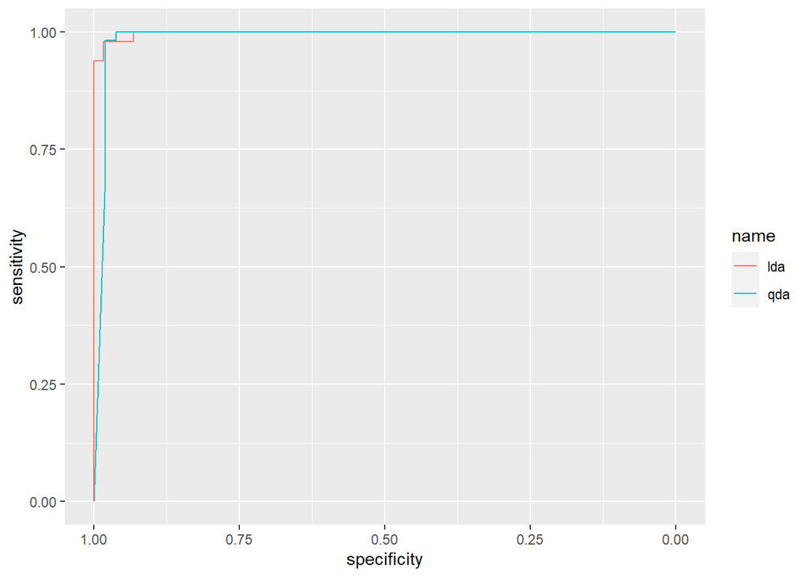

```r
ggroc(list(lda=roc_lda, qda=roc_qda))
```